# Final Assignment Machine Learning

Neli Dilkova-Gnoyke

27 Juni 2019

## Human Activity Recognition Assignment

The assignment is based on HAR, the Human Activity Recognition Assignment database created by Ugulino, W. et. al. Specifically, we are using the Weight Lifting Exercises dataset. This dataset is licensed under the Creative Commons license (CC BY-SA).

## Aim of the assignment

The aim is to predict the manner of exercise executions, stored in the variable “classe”.

## Model description

The dependent variable is categorical. Possibilities to predict the dependent variable are multinomial regression, random forest, naiive bayes.

I tried and compared two models: multinomial regression and random forest.

The original training dataset has the dimensions 19622 x 160.

### How was the model built

As the testing dataset does not include the variable “classe”, I split the training dataset into training and testing part. The Model was built using the new training part, which comprises of 70% of the original observations in the training dataset and 13737 observations.

Additionally, to assess the out of sample prediction error (out of bag error) especially for the Random Forest model, I used 10-fold cross validation.

The multinomial model was built in the following way:

1. **Preprocessing:**

All variables with a share of NA larger than 90%, or variance = 0 were removed. Categorical variables which had the same value in more than 90% of all cases were removed.

As the aim is to predict the quality of execution based on the execution parameters, all variables which were not connected to execution were removed as well (name of the participant, timestamp, window categorical and numeric). The dataset included some aggregations like means and standard deviations per participant. They were also removed.

After this cleaning, the dataset included 53 variables.

Then, I used centering and standardization to bring all independent variables on a similar scale.

2. **Variable selection:**

I calculated the bivariate correlation matrix of all standardized independent variables. In the next step, I removed the variables which correlated perfectly or almost perfectly (R >= 0.9) with another variable.

In the following graph, strong correlations are indicated in blue and pink color:

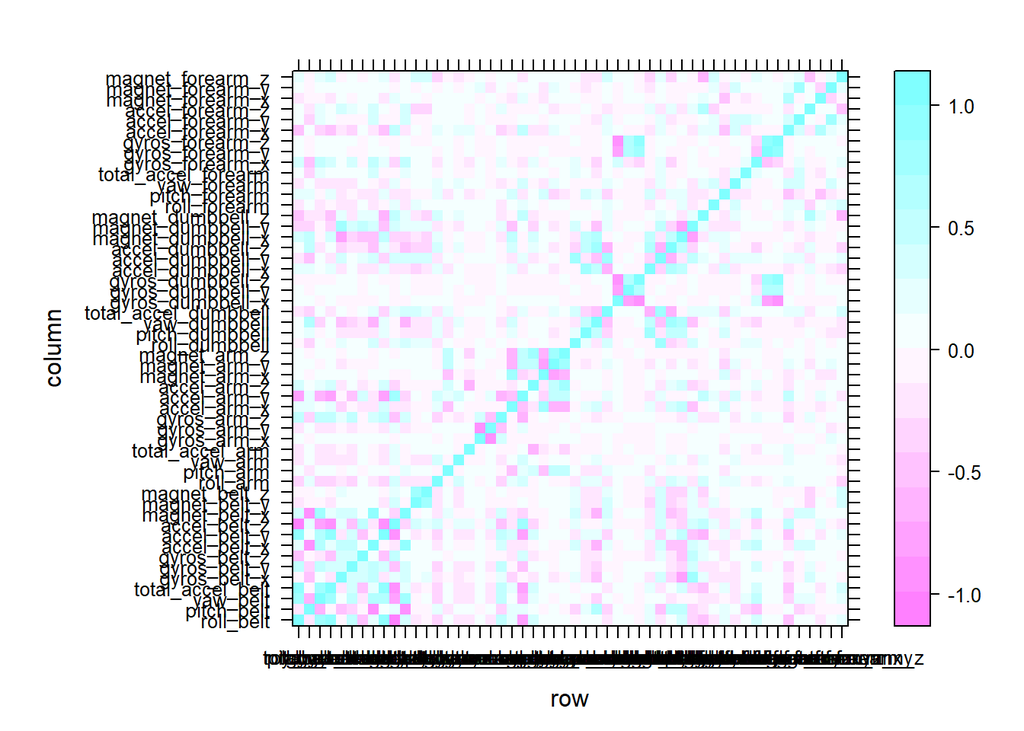

3. **Selection of a final model**

The final model I chose was the fandom forest, because it produced higher accuracy internally and in predicting the testing dataset.

Here is the summary of the multinomial model:

```
## Confusion Matrix and Statistics
##
##           Reference
## Prediction    A    B    C    D    E
##          A 1027  119   69   52   40
##          B   24  509   67   42  114
##          C   56   89  516   84   47
##          D   42   28   50  466   61
##          E    8   68   20   30  495
##
## Overall Statistics
##
##                Accuracy : 0.7308
##                  95% CI : (0.717, 0.7443)
##     No Information Rate : 0.2806
##     P-Value [Acc > NIR] : < 2.2e-16
##
##                   Kappa : 0.6583
##
##  Mcnemar's Test P-Value : < 2.2e-16
##
## Statistics by Class:
##
##                      Class: A Class: B Class: C Class: D Class: E
## Sensitivity            0.8876   0.6261   0.7147   0.6914   0.6539
## Specificity            0.9056   0.9254   0.9188   0.9475   0.9626
## Pos Pred Value         0.7858   0.6733   0.6515   0.7202   0.7971
## Neg Pred Value         0.9538   0.9097   0.9382   0.9402   0.9252
## Prevalence             0.2806   0.1972   0.1751   0.1635   0.1836
## Detection Rate         0.2491   0.1235   0.1252   0.1130   0.1201
## Detection Prevalence   0.3170   0.1834   0.1921   0.1569   0.1506
## Balanced Accuracy      0.8966   0.7757   0.8168   0.8195   0.8082
```

And here is the summary of the RF model:

```
## Confusion Matrix and Statistics
##
##           Reference
## Prediction    A    B    C    D    E
##          A 1157    0    0    0    0
##          B    0  813    0    0    0
##          C    0    0  722    0    0
##          D    0    0    0  674    0
##          E    0    0    0    0  757
##
## Overall Statistics
##
##                Accuracy : 1
##                  95% CI : (0.9991, 1)
##     No Information Rate : 0.2806
##     P-Value [Acc > NIR] : < 2.2e-16
##
##                   Kappa : 1
##
##  Mcnemar's Test P-Value : NA
##
## Statistics by Class:
##
##                      Class: A Class: B Class: C Class: D Class: E
## Sensitivity            1.0000   1.0000   1.0000   1.0000   1.0000
## Specificity            1.0000   1.0000   1.0000   1.0000   1.0000
## Pos Pred Value         1.0000   1.0000   1.0000   1.0000   1.0000
## Neg Pred Value         1.0000   1.0000   1.0000   1.0000   1.0000
## Prevalence             0.2806   0.1972   0.1751   0.1635   0.1836
## Detection Rate         0.2806   0.1972   0.1751   0.1635   0.1836
## Detection Prevalence   0.2806   0.1972   0.1751   0.1635   0.1836
## Balanced Accuracy      1.0000   1.0000   1.0000   1.0000   1.0000
```

```
##       OOB                 A                  B
##  Min.   :0.006115   Min.   :0.001792   Min.   :0.009406
##  1st Qu.:0.006406   1st Qu.:0.002304   1st Qu.:0.010534
##  Median :0.006697   Median :0.002560   Median :0.010534
##  Mean   :0.008232   Mean   :0.003088   Mean   :0.012974
##  3rd Qu.:0.006916   3rd Qu.:0.002560   3rd Qu.:0.011287
##  Max.   :0.084758   Max.   :0.044681   Max.   :0.131263
##        C                  D                 E
##  Min.   :0.005426   Min.   :0.01155   Min.   :0.002772
##  1st Qu.:0.006260   1st Qu.:0.01199   1st Qu.:0.003168
##  Median :0.006469   Median :0.01243   Median :0.003960
##  Mean   :0.008559   Mean   :0.01433   Mean   :0.005439
##  3rd Qu.:0.007095   3rd Qu.:0.01332   3rd Qu.:0.004356
##  Max.   :0.099111   Max.   :0.10378   Max.   :0.077949
```

## Prediction of 20 test cases

The prediction of 20 test cases with each model produced folowing results. The First series is the MNL prediction, the second the RF prediciton:

```
##  [1] B A B C C E D E A A C A B A E A C B B B
## Levels: A B C D E
```

```
##  [1] B A B A A E D B A A B C B A E E A B B B
## Levels: A B C D E
```